# CVS_medications

## 1. Business Problem Statement

As a data scientist at CVS, you have been tasked with developing a predictive model to identify patients with chronic diseases who are at risk of non-adherence to their prescribed medications. Medication non-adherence can lead to adverse health outcomes and increased healthcare costs. CVS aims to leverage its data resources and advanced analytics to predict non-adherence early and intervene with personalized strategies to improve patient outcomes.

## 2. Dataset Description

### 2.1. Table 1: Patient Medication History

This table contains information about patients' medication history, including prescriptions and refill patterns.

| Column name | Description |
| --- | --- |
| patient_id | Unique identifier for each patient |
| prescription_id | Unique identifier for each prescription |
| medication | Name of the prescribed medication |
| dosage | Dosage strength of the medication |
| quantity | Quantity of medication prescribed |
| prescribed_date | Date when the medication was prescribed |
| refill_date | Date when the medication was refilled |
| days_supply | Number of days' supply for each prescription |
| adherence | Binary indicator (0 or 1) for medication adherence |

### 2.2. Table 2: Patient Demographics and Clinical Data

This table provides demographic and clinical information about the patients.

| Column name | Description |
| --- | --- |
| patient_id | Unique identifier for each patient |
| age | Age of the patient |
| gender | Gender of the patient (Male/Female) |
| income | Annual income of the patient |
| location | Geographic location of the patient (e.g., city, state) |
| chronic_disease | Indicator for the presence of a chronic disease |
| comorbidity | Indicator for the presence of comorbidities |
| healthcare_utilization | Number of healthcare visits in the past year |

```python
import pandas as pd
# from google.colab import drive

# Mount Google Drive
# drive.mount('/content/drive')

file_path1 = 'https://storage.googleapis.com/datalynn-datasets/interview-challenge/pharmacetutical-and-biotechnology/CVS_medications/medication_data.csv'
file_path2 = 'https://storage.googleapis.com/datalynn-datasets/interview-challenge/pharmacetutical-and-biotechnology/CVS_medications/demographic_data.csv'

df_medication = pd.read_csv(file_path1)
df_demographics = pd.read_csv(file_path2)
```

## 3. Questions

### 3.1. Data Manipulation

- (3.1.1) In the Patient_Medication_History table, how would you identify and handle any duplicate entries for prescriptions, considering the columns such as patient_id, prescription_id, and prescribed_date?
- (3.1.2) Describe how you would join the Patient_Medication_History and Patient_Demographics_Clinical tables effectively. Once the tables are joined, you want to create a new feature that indicates the average number of medications prescribed per patient. How would you approach this?

#### **Answer 3.1.1.**

```python
import sqlite3

# Create an in-memory SQLite database
conn = sqlite3.connect(':memory:')

# Store the DataFrames in the database as tables
df_medication.to_sql('Patient_Medication_History', conn, index=False)
df_demographics.to_sql('Patient_Demographics_Clinical', conn, index=False)

# Identify duplicate entries
query = '''
SELECT patient_id, prescription_id, prescribed_date, COUNT(*) as count
FROM Patient_Medication_History
GROUP BY patient_id, prescription_id, prescribed_date
HAVING count > 1
'''
duplicate_entries = pd.read_sql_query(query, conn)

num_duplicates = duplicate_entries.shape[0]
print("Number of duplicate entries:", num_duplicates)

# Handle duplicate entries (remove duplicates)
query = '''
DELETE FROM Patient_Medication_History
WHERE rowid IN (
    SELECT rowid
    FROM (
        SELECT rowid,
               ROW_NUMBER() OVER (PARTITION BY patient_id, prescription_id, prescribed_date ORDER BY rowid) AS rn
        FROM Patient_Medication_History
    ) t
    WHERE rn > 1
)
'''
conn.execute(query)
conn.commit()

# Retrieve the updated dataframe from the database
df_medication = pd.read_sql_query("SELECT * FROM Patient_Medication_History", conn)

# Close the database connection
conn.close()
```

```
Number of duplicate entries: 50
```

#### **Answer 3.1.2.**

```python
import sqlite3

# Create an in-memory SQLite database
conn = sqlite3.connect(':memory:')

# Store the DataFrames in the database as tables
df_medication.to_sql('Patient_Medication_History', conn, index=False)
df_demographics.to_sql('Patient_Demographics_Clinical', conn, index=False)

# Join tables
join_query = '''
SELECT pmh.*, pdc.patient_id AS demographic_patient_id, pdc.age, pdc.gender, pdc.income, pdc.location, pdc.chronic_disease, pdc.comorbidity, pdc.healthcare_utilization
FROM Patient_Medication_History pmh
JOIN Patient_Demographics_Clinical pdc ON pmh.patient_id = pdc.patient_id
'''
joined_data = pd.read_sql_query(join_query, conn)

# Calculate average medication count per patient
avg_medication_count_query = '''
SELECT pmh.patient_id, AVG(CAST(pmh.prescription_id AS FLOAT)) AS avg_medication_count
FROM Patient_Medication_History pmh
GROUP BY pmh.patient_id
'''
avg_medication_count = pd.read_sql_query(avg_medication_count_query, conn)

# Merge the average medication count with the joined data
joined_data = pd.merge(joined_data, avg_medication_count, on='patient_id')

# Display the joined data with average medication count
print(joined_data.head())

# Close the database connection
conn.close()
```

```
   patient_id  prescription_id    medication dosage  quantity  \
0         425              719  Medication C   10mg        90
1         425              556  Medication C   10mg        62
2         425              539  Medication D   20mg        33
3         512              348  Medication A   20mg        69
4         512              449  Medication B   20mg        79

       prescribed_date          refill_date  days_supply  adherence  \
0  2022-01-17 00:10:53  2022-01-26 00:10:53           29          0
1  2019-08-11 20:24:23  2019-08-21 20:24:23           39          0
2  2021-06-29 09:22:21  2021-07-08 09:22:21           38          1
3  2021-03-10 19:26:17  2021-03-12 19:26:17           38          1
4  2019-02-15 19:21:49  2019-02-22 19:21:49           28          1

   demographic_patient_id  age  gender   income location  chronic_disease  \
0                     425   55  Female  $80,000   City A                0
1                     425   55  Female  $80,000   City A                0
2                     425   55  Female  $80,000   City A                0
3                     512   60    Male  $70,000   City A                0
4                     512   60    Male  $70,000   City A                0

   comorbidity  healthcare_utilization  avg_medication_count
0            1                       6            604.666667
1            1                       6            604.666667
2            1                       6            604.666667
3            0                       3            485.000000
4            0                       3            485.000000
```

### 3.2. Metric Selection

- (3.2.1) In the context of medication adherence, what are the limitations of using accuracy as an evaluation metric? Suggest an alternative metric that can better capture the importance of adherence.
- (3.2.2) Discuss the trade-offs between precision and recall in evaluating the adherence prediction model. Which metric would be more relevant for this problem, and why?

### 3.3. Feature Engineering

- (3.3.1) Given the Patient_Medication_History table, how would you engineer a new feature that captures the refill pattern for each patient's medication? Describe the steps you would take and the factors you would consider in creating this feature.
- (3.3.2) Suppose you want to analyze the relationship between medication adherence (from the Patient_Medication_History table) and the presence of comorbidities (from the Patient_Demographics_Clinical table). How would you engineer a feature that quantifies the interaction between these two variables? Discuss your approach and any transformations or calculations involved.

#### **Answer 3.3.1.**

```python
# 3.3.1
import pandas as pd
import numpy as np

# Convert 'prescribed_date' and 'refill_date' to datetime format
df_medication['prescribed_date'] = pd.to_datetime(df_medication['prescribed_date'])
df_medication['refill_date'] = pd.to_datetime(df_medication['refill_date'])

# Step 1: Sort the DataFrame by patient ID and prescribed date
df_medication_sorted = df_medication.sort_values(by=['patient_id', 'prescribed_date'])

# Step 2: Calculate the time difference between refill date and prescribed date for each patient and medication
df_medication_sorted['refill_duration'] = (df_medication_sorted['refill_date'] - df_medication_sorted['prescribed_date']).dt.days

# Step 3: Group the data by patient ID and medication
grouped_data = df_medication_sorted.groupby(['patient_id', 'medication'])

# Step 4: Compute statistical measures on the refill duration
refill_pattern = grouped_data['refill_duration'].agg(['mean', 'min', 'max', 'median']).reset_index()

# Step 5: Assign the computed statistical measures to each patient and medication combination as the new feature
df_medication = df_medication.merge(refill_pattern, on=['patient_id', 'medication'], how='left')

# Display the updated DataFrame
print(df_medication.head())
```

```
   patient_id  prescription_id    medication dosage  quantity  \
0         425              719  Medication C   10mg        90
1         512              348  Medication A   20mg        69
2         645              295  Medication D    5mg        82
3           6              973  Medication A    5mg        89
4         795              191  Medication D    5mg        53

      prescribed_date         refill_date  days_supply  adherence       mean  \
0 2022-01-17 00:10:53 2022-01-26 00:10:53           29          0   9.500000
1 2021-03-10 19:26:17 2021-03-12 19:26:17           38          1   2.000000
2 2021-09-05 22:09:48 2021-09-18 22:09:48           29          1  13.000000
3 2020-08-08 17:41:39 2020-08-10 17:41:39           17          1   6.000000
4 2020-01-31 08:40:14 2020-02-07 08:40:14           25          1   7.666667

   min  max  median
0    9   10     9.5
1    2    2     2.0
2   13   13    13.0
3    2   10     6.0
4    5   11     7.0
```

#### **Answer 3.3.2.**

```python
# Step 1: Merge the tables
merged_data = df_medication.merge(df_demographics[['patient_id', 'comorbidity']], on='patient_id', how='left')

# Step 2: Encode comorbidity presence
merged_data['comorbidity_presence'] = merged_data['comorbidity'].apply(lambda x: 1 if x == 1 else 0)

# Step 3: Group the data and calculate average adherence
grouped_data = merged_data.groupby('comorbidity_presence')
average_adherence = grouped_data['adherence'].mean()

# Step 4: Create the interaction feature
interaction_feature = average_adherence[1] - average_adherence[0]

# Display the interaction feature
print("Interaction Feature (Difference in Average Adherence):", interaction_feature)
```

```
Interaction Feature (Difference in Average Adherence): 0.04260425699701553
```

### 3.4. Model Selection

- With our CVS dataset containing both numerical features and categorical variables, what initial model would you choose and why? Consider the nature of the features and the task at hand.

### 3.5. Model Optimization and Interpretation

- (3.5.1) Continuing from the previous question, assuming you have selected a random forest algorithm to predict medication adherence, how would you determine the optimal hyperparameters for the model? Discuss different approaches you can take, and explain the trade-offs involved in selecting the best hyperparameters.
- (3.5.2) Imagine you have successfully optimized a random forest model for the CVS data challenge. However, the model's interpretability is equally important for stakeholders. How would you address the trade-off between model performance and interpretability? Discuss techniques or approaches you would use to enhance the interpretability of the random forest model without significantly sacrificing its performance.

#### **Answer 3.5.1.**

```python
import pandas as pd
from sklearn.ensemble import RandomForestClassifier
from sklearn.model_selection import GridSearchCV, train_test_split
from sklearn.metrics import accuracy_score

# Select the categorical columns for one-hot encoding
categorical_columns = ['medication', 'dosage']

# Perform one-hot encoding on the categorical columns
df_encoded = pd.get_dummies(df_medication, columns=categorical_columns)

# Convert datetime columns to numeric representation
df_encoded['prescribed_date'] = (df_medication['prescribed_date'] - pd.Timestamp("1970-01-01")) // pd.Timedelta('1s')
df_encoded['refill_date'] = (df_medication['refill_date'] - pd.Timestamp("1970-01-01")) // pd.Timedelta('1s')

# Remove 'patient_id' and 'prescription_id' columns
df_encoded = df_encoded.drop(['patient_id', 'prescription_id'], axis=1)

# Split the data into features (X) and target variable (y)
X = df_encoded.drop('adherence', axis=1)
y = df_encoded['adherence']

# Split the data into train and test sets
X_train, X_test, y_train, y_test = train_test_split(X, y, test_size=0.2, random_state=0)

# Define the parameter grid for hyperparameter tuning
param_grid = {
    'n_estimators': [100, 200, 300],
    'max_depth': [None, 5, 10],
    'min_samples_split': [2, 5, 10]
}

# Create a Random Forest classifier
rf = RandomForestClassifier(random_state=0)

# Perform Grid Search Cross-Validation to find the best hyperparameters
grid_search = GridSearchCV(estimator=rf, param_grid=param_grid, cv=5)
grid_search.fit(X_train, y_train)

# Get the best model and its hyperparameters
best_rf = grid_search.best_estimator_
best_params = grid_search.best_params_

# Make predictions on the test set using the best model
y_pred = best_rf.predict(X_test)

# Evaluate the model performance
accuracy = accuracy_score(y_test, y_pred)

# Print the best hyperparameters and model accuracy
print("Best Hyperparameters:", best_params)
print("Accuracy:", accuracy)
```

```
Best Hyperparameters: {'max_depth': 5, 'min_samples_split': 2, 'n_estimators': 100}
Accuracy: 0.8067226890756303
```

#### **Answer 3.5.2.**

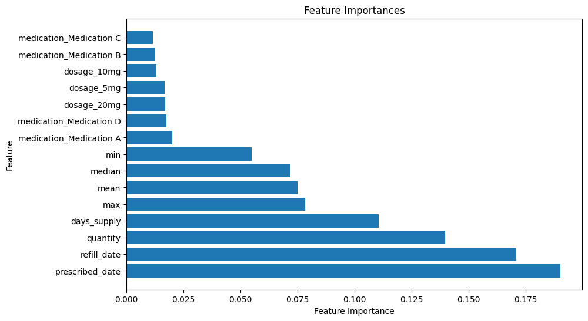

```python
import matplotlib.pyplot as plt

# Assuming 'best_rf' is the trained random forest model

# Get feature importances from the model
feature_importances = best_rf.feature_importances_

# Create a sorted list of feature names and their importances
feature_names = X.columns
importance_list = sorted(zip(feature_names, feature_importances), key=lambda x: x[1], reverse=True)

# Plot feature importances
plt.figure(figsize=(10, 6))
plt.barh(range(len(importance_list)), [val[1] for val in importance_list], align='center')
plt.yticks(range(len(importance_list)), [val[0] for val in importance_list])
plt.xlabel('Feature Importance')
plt.ylabel('Feature')
plt.title('Feature Importances')
plt.show()
```

```python
!pip install lime
!pip install shap
```

```
     ━━━━━━━━━━━━━━━━━━━━━━━━━━━━━━━━━━━━━━━ 275.7/275.7 kB 5.8 MB/s eta 0:00:00
  Preparing metadata (setup.py) ... done
     ━━━━━━━━━━━━━━━━━━━━━━━━━━━━━━━━━━━━━━━ 572.6/572.6 kB 9.2 MB/s eta 0:00:00
```

```python
import lime
import lime.lime_tabular
import shap

# Initialize LIME explainer
explainer = lime.lime_tabular.LimeTabularExplainer(X_train.values, feature_names=X_train.columns, class_names=['Non-Adherence', 'Adherence'])

# Choose a specific instance for explanation
instance_idx = 0
instance = X_test.iloc[instance_idx].values
explanation = explainer.explain_instance(instance, best_rf.predict_proba, num_features=len(X_train.columns))

# Get LIME feature importance
lime_importance = explanation.as_list()

# Initialize SHAP explainer
explainer = shap.Explainer(best_rf)

# Calculate SHAP values
shap_values = explainer.shap_values(X_test)

# Choose a specific instance for explanation
instance_shap_values = shap_values[instance_idx]

# Get SHAP feature importance
shap_importance = list(zip(X_train.columns, instance_shap_values))
```

```
X does not have valid feature names, but RandomForestClassifier was fitted with feature names
```

```python
# Show LIME explanation in notebook
explanation.show_in_notebook()
```

[output not shown]

Explanation of SHAP summary plot:

```
No data for colormapping provided via 'c'. Parameters 'vmin', 'vmax' will be ignored
```

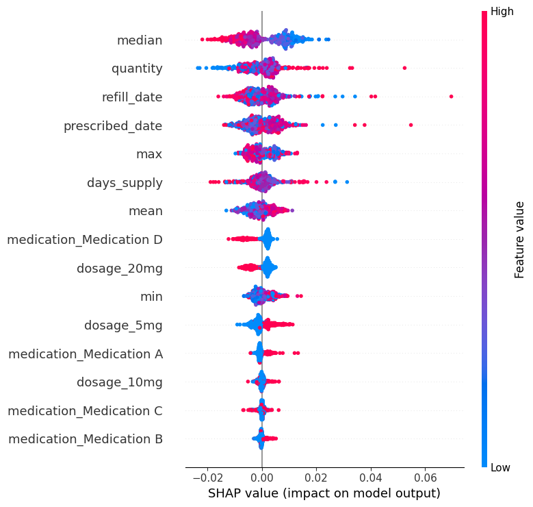

```python
# Show SHAP plot in notebook
figure = plt.figure()
shap.summary_plot(instance_shap_values, X_test)
```

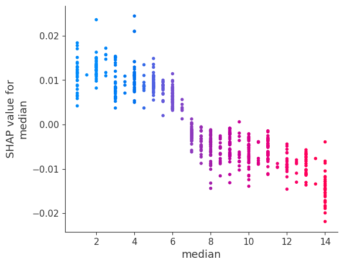

```python
# Dependence Plot on Median feature
shap.dependence_plot('median', shap_values[0], X_test, interaction_index="median")
```

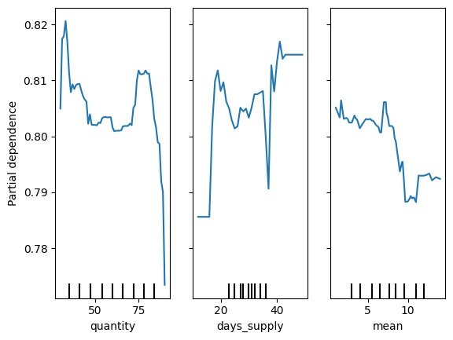

```python
from sklearn.inspection import PartialDependenceDisplay
import matplotlib.pyplot as plt

# Define the features for which you want to plot PDPs
features = ['quantity', 'days_supply', 'mean']

# Create a PartialDependenceDisplay object
pdp_display = PartialDependenceDisplay.from_estimator(best_rf, X_train, features)
```

### 3.6. Business Insights

- In the context of the CVS data challenge, you have developed a machine learning model to predict medication adherence. How would you translate the model's predictions into actionable insights for CVS? Discuss how you would communicate the findings to stakeholders and recommend specific interventions or strategies to improve medication adherence based on the model's outputs.